# Analysis of The National Health and Nutrition Examination Survey (NHANES)

Joanne Musa

Feb 4, 2025

# 1 INTRODUCTION

```r
nhanes <- read.csv("https://jmusa3.github.io/jmusa/nhanes.csv")


#create missing values in some variables

# Set seed for reproducibility
set.seed(123)

# Determine the number of missing values (4% of total rows)
num_missing <- round(0.04 * nrow(nhanes))

# Randomly select row indices to introduce missing values
missing_indices <- sample(1:nrow(nhanes), num_missing, replace = FALSE)

# Set selected rows in body.weight to NA
nhanes$body.weight[missing_indices] <- NA

# Verify missing values
#sum(is.na(nhanes$body.weight))


# Set seed for reproducibility
set.seed(456)

# Determine the number of missing values (5% of total rows)
num_missing <- round(0.05 * nrow(nhanes))

# Randomly select row indices to introduce missing values
missing_indices <- sample(1:nrow(nhanes), num_missing, replace = FALSE)

# Set selected rows in body.weight to NA
nhanes$cholestrol[missing_indices] <- NA

# Verify missing values
#sum(is.na(nhanes$cholestrol))
```

The National Health and Nutrition Examination Survey (NHANES) is a program conducted by the National Center for Health Statistics (NCHS), a division of the Centers for Disease Control and Prevention (CDC). NHANES has been conducted in various forms since the early 1960s, with the current continuous survey format beginning in 1999. The survey is designed to assess the health and nutritional status of adults and children in the United States through a combination of interviews, physical examinations, and laboratory tests. Data is collected from a nationally representative sample of the U.S. population using a complex, multistage probability sampling design. Participants undergo household interviews followed by health examinations at mobile examination centers (MECs), where trained medical professionals collect biological samples and conduct clinical assessments. The NHANES data provides critical insights into public health trends, helping policymakers, researchers, and healthcare professionals make informed decisions on national health priorities. The purpose of this study is to assess the health and nutritional status of the study participants with metrics such as high blood pressure.

There are 15 features and 7927 observations in this data set. These features are listed below.

1. obs: Respondent Identification Number
2. psu: Pseudo-PSU 1,2 psu
3. stratum: Pseudo-stratum (01 - 49)
4. stat.weight: Statistical weight (225.93 - 139744.9)
5. age: Age (years)
6. sex: 0 = Female, 1 = Male sex
7. race: Race (1 = White; 2 = Black; 3 = Other)
8. body.weight: Body Weight (pounds)
9. height: Standing Height (inches)
10. avg.sbp: Average Systolic BP (mm/Hg)
11. avg.dbp: Average Diastolic BP (mm/Hg)
12. past.smk: Has respondent smoked > 100 cigarettes in life (1 = Yes, 2 = No)
13. current.smk: Does respondent smoke cigarettes now? (1 = Yes, 2 = No)
14. cholestrol: Serum Cholesterol (mg/100ml)
15. hbp: High Blood Pressure (0 if PEPMNK1R <= 140; 1 if PEPMNK1R > 140)

The obs, psu, stratum, and stat.weight variables are not included in this analysis because they do not directly provide health-related information.

The data set has 317 missing values for body weight and 396 missing values for cholesterol.

# 2 EDA

## 2.1 Missing Values

Body weight and height has a correlation of 0.45712488. In turn, the 317 missing body weight values will be imputed using height.

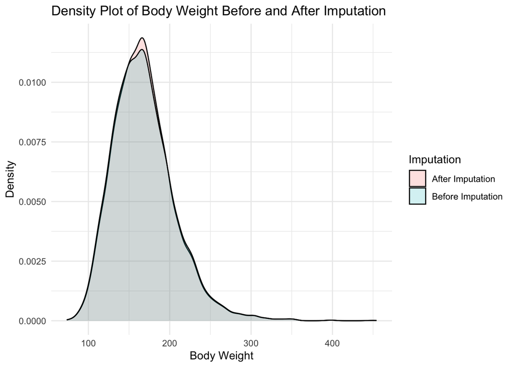

```r
# Store original body.weight values (before imputation)
nhanes$body.weight_original <- nhanes$body.weight

# Fit a linear model (excluding missing values)
lm_model <- lm(body.weight ~ height, data = nhanes, na.action = na.omit)

# Identify missing indices
missing_idx <- which(is.na(nhanes$body.weight))

# Predict missing values using the model
nhanes$body.weight[missing_idx] <- predict(lm_model, newdata = nhanes[missing_idx, ])

# Create a data frame for plotting
plot_data <- data.frame(
  body.weight = c(nhanes$body.weight_original, nhanes$body.weight),
  Imputation = rep(c("Before Imputation", "After Imputation"), each = nrow(nhanes))
)

# Plot density
ggplot(plot_data, aes(x = body.weight, fill = Imputation)) +
  geom_density(alpha = 0.2) +
  labs(title = "Density Plot of Body Weight Before and After Imputation",
       x = "Body Weight",
       y = "Density") +
  theme_minimal()
```

The distribution before and after imputation is similar. In turn, the imputation did not change the distribution of body weight.

The feature that is most correlated to cholesterol is age. In turn, 396 missing values of cholesterol will be imputed with age.

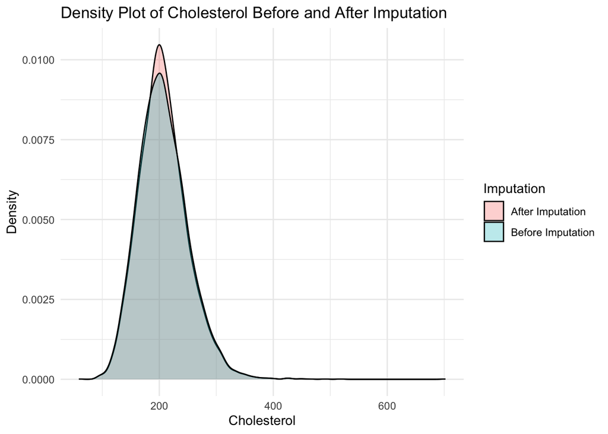

```r
# Store original cholesterol values (before imputation)
nhanes$cholestrol_original <- nhanes$cholestrol

# Fit a linear model using available data (excluding missing values)
lm_model <- lm(cholestrol ~ age, data = nhanes, na.action = na.omit)

# Identify missing indices
missing_idx <- which(is.na(nhanes$cholestrol))

# Predict missing values using the model
nhanes$cholestrol[missing_idx] <- predict(lm_model, newdata = nhanes[missing_idx, ])

# Create a data frame for plotting
plot_data <- data.frame(
  cholestrol = c(nhanes$cholestrol_original, nhanes$cholestrol),
  Imputation = rep(c("Before Imputation", "After Imputation"), each = nrow(nhanes))
)

# Density Plot with Transparency
ggplot(plot_data, aes(x = cholestrol, fill = Imputation)) +
  geom_density(alpha = 0.3) +  # Increase transparency
  labs(title = "Density Plot of Cholesterol Before and After Imputation",
       x = "Cholesterol",
       y = "Density") +
  theme_minimal()
```

The distribution of cholesterol did not change significantly after imputing missing values using age.

## 2.2 Distribution of Individual Features

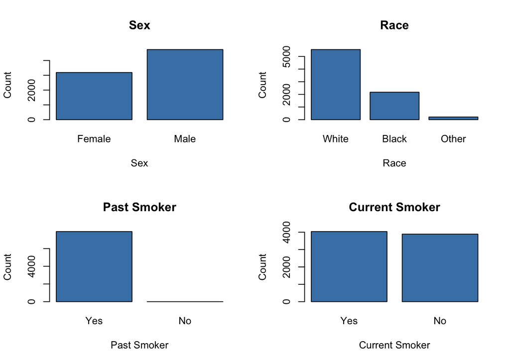

```r
# Convert variables to factors with proper labels
nhanes$sex <- factor(nhanes$sex, levels = c(0, 1), labels = c("Female", "Male"))
nhanes$race <- factor(nhanes$race, levels = c(1, 2, 3), labels = c("White", "Black", "Other"))
nhanes$past.smk <- factor(nhanes$past.smk, levels = c(1, 2), labels = c("Yes", "No"))
nhanes$current.smk <- factor(nhanes$current.smk, levels = c(1, 2), labels = c("Yes", "No"))

# Create frequency tables
sex_count <- table(nhanes$sex)

race_count <- table(nhanes$race)

past.smk_count <- table(nhanes$past.smk)

current.smk_count <- table(nhanes$current.smk)


par(mfrow = c(2, 2))

# Plot the bar charts
barplot(height = sex_count, col = "steelblue", main = "Sex", xlab = "Sex", ylab = "Count")

barplot(height = race_count, col = "steelblue", main = "Race", xlab = "Race", ylab = "Count")

barplot(height = past.smk_count, col = "steelblue", main = "Past Smoker", xlab = "Past Smoker", ylab = "Count")

barplot(height = current.smk_count, col = "steelblue", main = "Current Smoker", xlab = "Current Smoker", ylab = "Count")
```

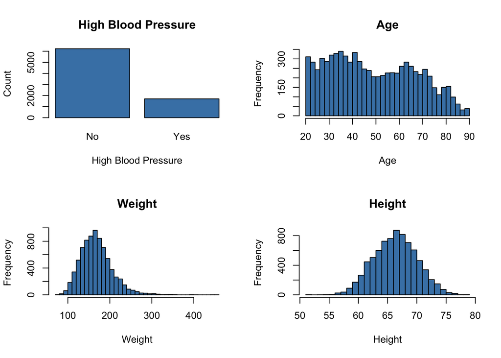

```r
par(mfrow = c(2,2))


nhanes$hbp <- factor(nhanes$hbp, levels = c(0, 1), labels = c("No", "Yes"))
hbp_count <- table(nhanes$hbp)


barplot(height = hbp_count, col = "steelblue", main = "High Blood Pressure", xlab = "High Blood Pressure", ylab = "Count")


hist(nhanes$age, col = "steelblue",
     main = "Age",
     xlab = "Age", ylab = "Frequency",
     breaks = 30)

hist(nhanes$body.weight, col = "steelblue",
     main = "Weight",
     xlab = "Weight", ylab = "Frequency",
     breaks = 30)

hist(nhanes$height, col = "steelblue",
     main = "Height",
     xlab = "Height", ylab = "Frequency",
     breaks = 30)
```

Most participants do not have high blood pressure. The age of participants varies from about 20 to about 90. The height distribution is roughly symmetric. The body weight distribution is skewed right due to some high outliers. The high outliers may indicate obesity. In turn a feature which calculates BMI is created to determine observations are classified as obese. According to the CDC (https://www.cdc.gov/nccdphp/dnpao/data-trends-maps/help/npao_dtm/definitions.html), Adult obesity is defined as body mass index (BMI) ≥ 30.0. Another feature named obese, based on BMI, is created, where 0 = no and 1 = yes.

```r
# Create BMI feature
nhanes$BMI <- (nhanes$body.weight * 703) / (nhanes$height * nhanes$height)
# Round the BMI to the nearest ones place
nhanes$BMI <- round(nhanes$BMI, 0)

# Create the obese feature based on BMI
nhanes$obese <- ifelse(nhanes$BMI >= 30, 1, 0)
```

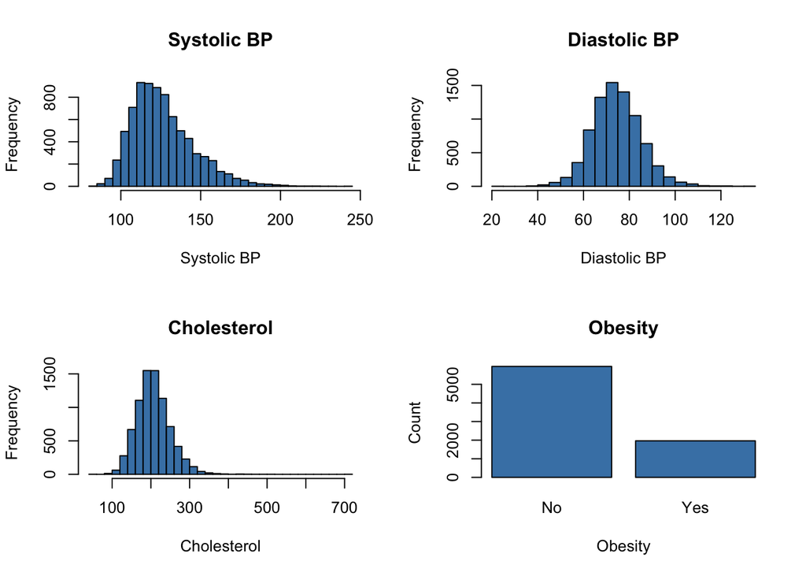

```r
par(mfrow = c(2,2))

hist(nhanes$avg.sbp, col = "steelblue",
     main = "Systolic BP",
     xlab = "Systolic BP", ylab = "Frequency",
     breaks = 30)

hist(nhanes$avg.dbp, col = "steelblue",
     main = "Diastolic BP",
     xlab = "Diastolic BP", ylab = "Frequency",
     breaks = 30)

hist(nhanes$cholestrol, col = "steelblue",
     main = "Cholesterol",
     xlab = "Cholesterol", ylab = "Frequency",
     breaks = 30)

nhanes$obese <- factor(nhanes$obese, levels = c(0, 1), labels = c("No", "Yes"))

obese_count <- table(nhanes$obese)

barplot(height = obese_count, col = "steelblue", main = "Obesity", xlab = "Obesity", ylab = "Count")
```

Systolic BP and cholesterol have skewed right distributions. Diastolic BP is roughly symmetric. Of the 7927 participants, 1964 are obese.

## 2.3 Relationship between Features

All pairwise scatter plots for quantitative features are examined. A correlation matrix is also created for these pairs.

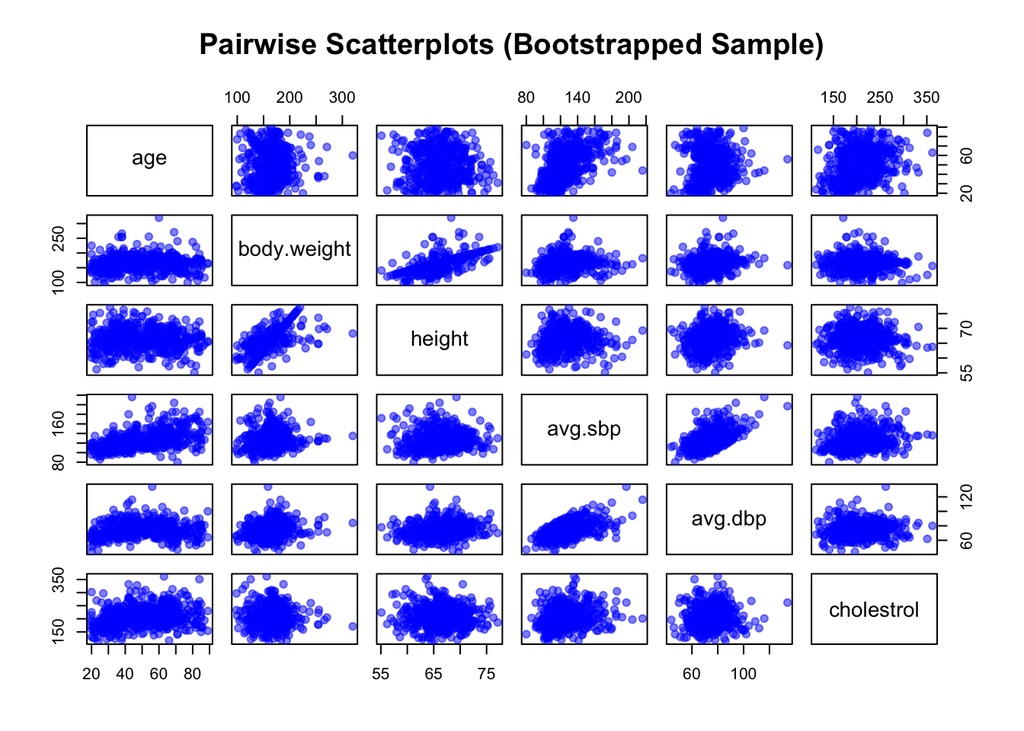

```r
# Set seed for reproducibility
set.seed(123)

# Sample 500 rows (adjust the number as needed)
sample_indices <- sample(nrow(nhanes), size = 500, replace = TRUE)
sampled_data <- nhanes[sample_indices, c("age", "body.weight", "height", "avg.sbp", "avg.dbp", "cholestrol")]

# Create a pairwise scatterplot matrix with the sampled data
pairs(sampled_data,
      main = "Pairwise Scatterplots (Bootstrapped Sample)",
      pch = 19,           # Shape of the points (circle)
      col = rgb(0, 0, 1, 0.5)  # Color with transparency (blue)
)
```

```r
nhanes_subset <- nhanes[, c("age", "body.weight", "height", "avg.sbp", "avg.dbp", "cholestrol")]

# Compute the correlation matrix
cor_matrix <- cor(nhanes_subset, use = "pairwise.complete.obs")

# Print the correlation matrix
print(cor_matrix)
```

```
                    age body.weight      height    avg.sbp   avg.dbp
age          1.00000000 -0.01291432 -0.08538971 0.55641362 0.1143690
body.weight -0.01291432  1.00000000  0.46218502 0.13203790 0.2833548
height      -0.08538971  0.46218502  1.00000000 0.01379185 0.2060106
avg.sbp      0.55641362  0.13203790  0.01379185 1.00000000 0.5213667
avg.dbp      0.11436905  0.28335482  0.20601064 0.52136671 1.0000000
cholestrol   0.27642888  0.09254047 -0.06465076 0.22489165 0.1641338
             cholestrol
age          0.27642888
body.weight  0.09254047
height      -0.06465076
avg.sbp      0.22489165
avg.dbp      0.16413379
cholestrol   1.00000000
```

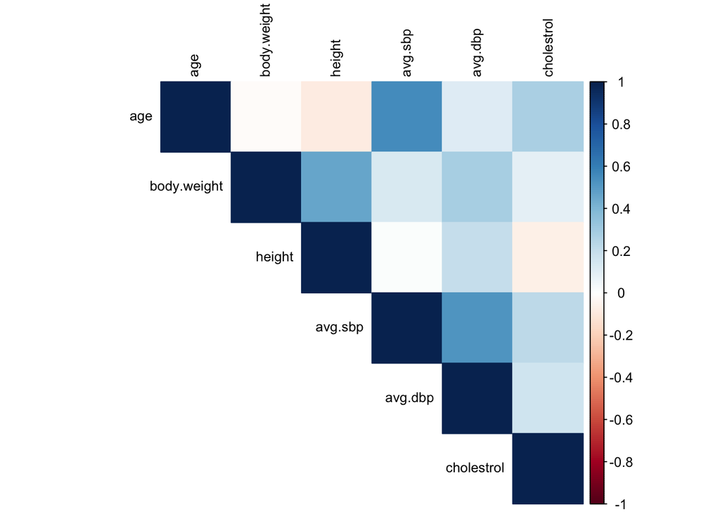

```r
corrplot(cor_matrix, method = "color", type = "upper", tl.col = "black", tl.cex = 0.8)
```

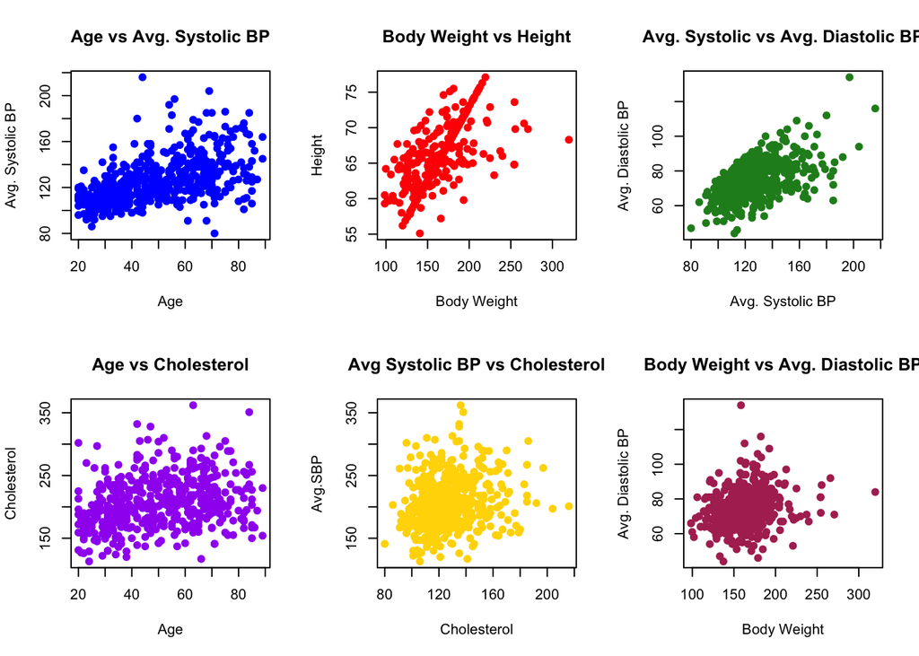

```r
# Set seed for reproducibility
set.seed(123)

# Bootstrap a smaller sample (adjust size as needed)
sample_indices <- sample(nrow(nhanes), size = 500, replace = TRUE)
sampled_data <- nhanes[sample_indices, ]

# Set up a 2x3 plotting grid
par(mfrow = c(2, 3))

# Scatterplot for Age and Avg. Systolic Blood Pressure
plot(sampled_data$age, sampled_data$avg.sbp, main = "Age vs Avg. Systolic BP",
     xlab = "Age", ylab = "Avg. Systolic BP", col = "blue", pch = 19)

# Scatterplot for Body Weight and Height
plot(sampled_data$body.weight, sampled_data$height, main = "Body Weight vs Height",
     xlab = "Body Weight", ylab = "Height", col = "red", pch = 19)

# Scatterplot for Avg. Systolic Blood Pressure and Avg. Diastolic Blood Pressure
plot(sampled_data$avg.sbp, sampled_data$avg.dbp, main = "Avg. Systolic vs Avg. Diastolic BP",
     xlab = "Avg. Systolic BP", ylab = "Avg. Diastolic BP", col = "forestgreen", pch = 19)

# Scatterplot for Age and Cholesterol
plot(sampled_data$age, sampled_data$cholestrol, main = "Age vs Cholesterol",
     xlab = "Age", ylab = "Cholesterol", col = "purple", pch = 19)

# Scatterplot for Avg. Systolic BP and Cholesterol
plot(sampled_data$avg.sbp, sampled_data$cholestrol, main = "Avg Systolic BP vs Cholesterol",
     xlab = "Cholesterol", ylab = "Avg.SBP", col = "gold", pch = 19)

# Scatterplot for Body Weight and Avg. Diastolic Blood Pressure
plot(sampled_data$body.weight, sampled_data$avg.dbp, main = "Body Weight vs Avg. Diastolic BP",
     xlab = "Body Weight", ylab = "Avg. Diastolic BP", col = "maroon", pch = 19)
```

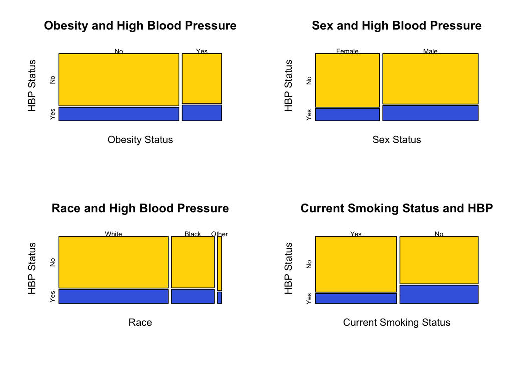

```r
# Set up a 2x2 plotting grid
par(mfrow = c(2, 2))

# Create a contingency table
obese_hbp_table <- table(nhanes$obese, nhanes$hbp)

# Generate mosaic plot
mosaicplot(obese_hbp_table,
           col = c("gold", "royalblue"),
           main = "Obesity and High Blood Pressure",
           xlab = "Obesity Status",
           ylab = "HBP Status",
           border = "black")


# Create a contingency table
sex_hbp_table <- table(nhanes$sex, nhanes$hbp)

# Generate mosaic plot
mosaicplot(sex_hbp_table,
           col = c("gold", "royalblue"),
           main = "Sex and High Blood Pressure",
           xlab = "Sex Status",
           ylab = "HBP Status",
           border = "black")


# Create a contingency table
race_hbp_table <- table(nhanes$race, nhanes$hbp)

# Generate mosaic plot
mosaicplot(race_hbp_table,
           col = c("gold", "royalblue"),
           main = "Race and High Blood Pressure",
           xlab = "Race",
           ylab = "HBP Status",
           border = "black")


# Create a contingency table
current.smk_hbp_table <- table(nhanes$current.smk, nhanes$hbp)

# Generate mosaic plot
mosaicplot(current.smk_hbp_table,
           col = c("gold", "royalblue"),
           main = "Current Smoking Status and HBP",
           xlab = "Current Smoking Status",
           ylab = "HBP Status",
           border = "black")
```

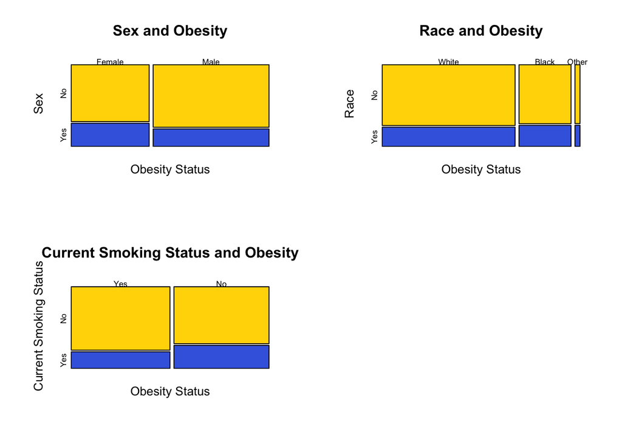

```r
# Set up a 2x2 plotting grid
par(mfrow = c(2, 2))

# Create a contingency table
obese_sex_table <- table(nhanes$sex, nhanes$obese)

# Generate mosaic plot
mosaicplot(obese_sex_table,
           col = c("gold", "royalblue"),
           main = "Sex and Obesity",
           xlab = "Obesity Status",
           ylab = "Sex",
           border = "black")


# Create a contingency table
obese_race_table <- table(nhanes$race, nhanes$obese)

# Generate mosaic plot
mosaicplot(obese_race_table,
           col = c("gold", "royalblue"),
           main = "Race and Obesity",
           xlab = "Obesity Status",
           ylab = "Race",
           border = "black")


# Create a contingency table
obese_smoke_table <- table(nhanes$current.smk, nhanes$obese)

# Generate mosaic plot
mosaicplot(obese_smoke_table,
           col = c("gold", "royalblue"),
           main = "Current Smoking Status and Obesity",
           xlab = "Obesity Status",
           ylab = "Current Smoking Status",
           border = "black")
```

An association exists between sex adn current smoking status with obesity.